# Corporate Finance

Lecture 1: Introduction

Camilo Saldarriaga

Finance Department, ESCP Business School, 2026/2027

## Objectives

## Presentation

1. Name
2. Where are you from?
3. Academic background?
4. Fun fact or thing you like?

## Course outline

1. Chapter 10: Capital Markets and the Pricing of Risk
2. Chapter 11: Optimal Portfolio Choice
3. Chapter 11: Capital Asset Pricing Model
4. Chapter 13: Investor Behavior and Capital Market Efficiency
5. Chapter 12: Estimating the Cost of Capital
6. Chapter 14: Capital Structure in a Perfect Market
7. Chapter 15: Debt and Taxes
8. Chapter 17: Payout Policy
9. Chapters 23-24: Introduction to Long-term Financing
10. Chapters 20 & 30: Options and Risk Management

## Assessment methods

- Overall grade:
  - Continuous assessment
    - Excel group assignment (20%)
    - Pearson Mylab weekly homework (10%)
  - Final exam (70%)
    - Closed-book, paper-based, on-campus exam.
    - Duration of two hours.
    - Mix of multiple choice questions, calculation questions including possibly questions to draw figures with short answers interpreting the results, and few short open-answer questions.
    - Formula sheet will be provided and students need to bring a calculator.
    - Last year’s exam will be provided in November.
- Students need a minimum grade of 8 in the final exam and a minimum overall grade of 10 to pass the course.

## Bibliography

- The reference book is Berk, Jonathan and Peter DeMarzo, “Corporate Finance,” Pearson Education.
- The course will cover the Parts IV, V and VII … …but in less detail than the book.
- An electronic version of the textbook is available on MyFinanceLab.

## Documents and learning resources

- I will update the slides weekly.
- Blackboard: https://escp.blackboard.com/ $\Rightarrow$ Additional materials and Q&A forum
- Pearson Mylab: MyFinanceLab (access via blackboard)
  - Students are required to complete weekly assignments in MyFinanceLab.
  - These homeworks are made available after each lecture block and are due before the start of the next lecture block. Late submission will not be accepted.
  - Each homework contains five questions that cover a two-hour lecture. For four-hour lectures, two such homeworks will be made available (covering a total of ten questions).
  - There will be twelve homeworks in total.
  - It is recommended to study the additional exercises for each chapter available in the multimedia library.

## Contact

- Camilo Saldarriaga
- Mail: juan_camilo.saldarriaga@edu.escp.eu

Some class rules

**1. No digital devices rule**

[figure not shown]

**2. Do not have parallel conversations while the professor talks**

*If you would rather talk through the whole class, it is better not to come at all, and to accept the consequences*

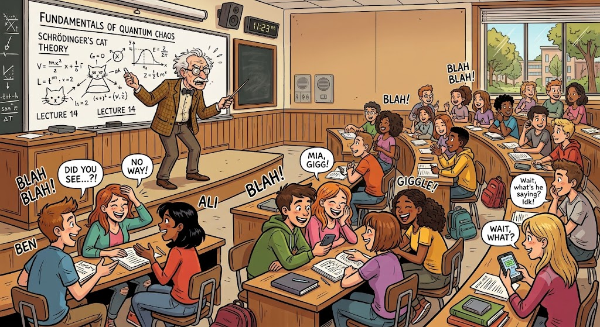

**3. Attendance will be taken at the beginning of every class**

The final assignment